# Tutorial on statistical power analysis via simulations in R

```r
# accordingly, we'll use uneven number of trials per condition
n_trials <- round(faces[,.N, by =.(uid, stim_gender)][,mean(N),by=.(stim_gender)]$V1)

simulate_mix <- function (n_subjects, n_trials, mean_est, cov_mat, avg_sd){
  # generate means by subject
  sim_data <- data.table(mvrnorm(n = n_subjects, mean_est, cov_mat))
  # create subject IDs
  sim_data[,uid:=1:.N]
  # for each condition, generate trials
  sim_data[,rbind(
    data.frame(stim_gender = 'M', logRT = rnorm(n_trials[1], M, avg_sd)),
    data.frame(stim_gender = 'F', logRT = rnorm(n_trials[2], F, avg_sd))), by = .(uid)]
}


# example: simulate data with the original number of trials and subjects
ex_sim <- simulate_mix(n_subjects = 60, n_trials = c(20, 10), mean_est = mean_est, cov_mat = cov_mat, avg_sd = avg_sd)
ex_sim[,.N, by = .(uid, stim_gender)]
```

| uid | stim_gender | N |
| --- | --- | --- |
| 1 | M | 20 |
| 1 | F | 10 |
| 2 | M | 20 |
| 2 | F | 10 |
| 3 | M | 20 |
| 3 | F | 10 |
| 4 | M | 20 |
| 4 | F | 10 |
| 5 | M | 20 |
| 5 | F | 10 |

[output cut: 110 more lines]

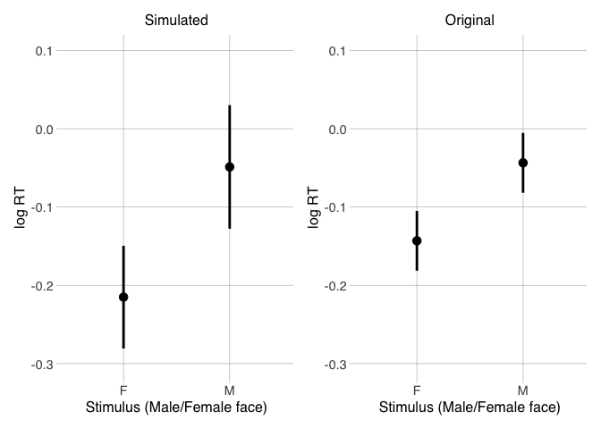

```r
ex_sim[,stim_gender:=factor(stim_gender, levels = c('F','M'))]

# compare original and simulated data
p1 <- plot.pointrange(ex_sim, aes(x = stim_gender, y = logRT), wid = 'uid', do_aggregate = T) + labs(x = 'Stimulus (Male/Female face)', y = 'log RT', title = 'Simulated')
p2 <- plot.pointrange(faces, aes(x = stim_gender, y = logRT), wid = 'uid', within_subj = T, do_aggregate = T) + labs(x = 'Stimulus (Male/Female face)', y = 'log RT', title = 'Original')

(p1+p2)*coord_cartesian(ylim = c(-0.3, 0.1))
```

The original and the simulated data should look relatively similar (note that we have made simplifications when approximating the data model so they won’t be exactly similar; besides, it is simulated data).

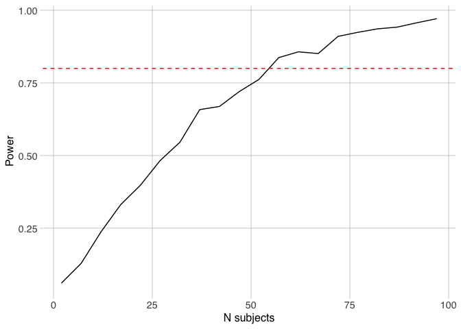

```r
# to make things easier, we will make another function that will aggregate the output of simulate_mix and compute p-value
simulate_mix_aggr <-  function (n_subjects, n_trials, mean_est, cov_mat, avg_sd){
  sim_data <- simulate_mix(n_subjects = n_subjects, n_trials = n_trials, mean_est = mean_est, cov_mat = cov_mat, avg_sd = avg_sd)

  sim_data_aggr <- sim_data[,.(logRT = mean(logRT)), by = .(uid, stim_gender)]
  (t.test(logRT~stim_gender, sim_data_aggr, paired = T))$p.value
}

# now we will simulate data for different numbers of subjects like we did before
# to speed up simulations, we will generate n_subjects in steps of five

sim_dt <- data.table(expand.grid(n_subjects = seq(2,100,5), n_reps = 1:max_n_reps))

# compute p-value for each replication and each sample size
sim_dt[, p_val:= simulate_mix_aggr(n_subjects, n_trials, mean_est, cov_mat, avg_sd), by = .(n_subjects, n_reps)]

# compute the average probability of getting a significant result
sim_dt_avg<-sim_dt[,.(power = mean(as.numeric(p_val<0.05))), by = n_subjects]

ggplot(sim_dt_avg, aes(x = n_subjects, y = power))+
  geom_line(stat='summary', fun.y = mean) +
  geom_hline(yintercept = 0.8, linetype = 2, color = 'red') +
  labs(y = 'Power', x = 'N subjects')
```

An alternative to changing the number of subjects is changing the number of trials. So how do trial numbers affect study power?

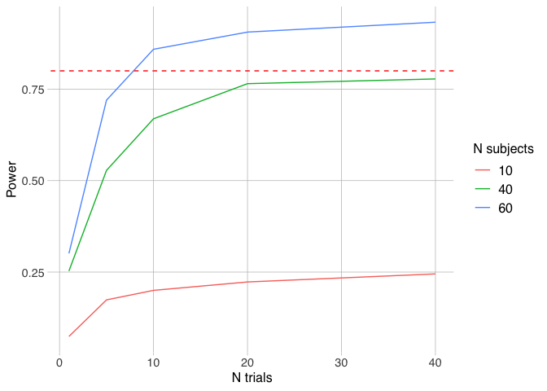

```r
# we will keep the same proportion of trials by condition, so we only need to set the number of trials in one of them
# we will also check three sample sizes

sim_dt_by_trial <- data.table(expand.grid(n_subjects = c(10,40,60), n_reps = 1:max_n_reps, n_trials_f = c(1, 5, 10, 20, 40)))

# compute p-value for each replication and each sample size and trial number
sim_dt_by_trial[, p_val:= simulate_mix_aggr(n_subjects, n_trials = c(n_trials_f*2, n_trials_f), mean_est, cov_mat, avg_sd), by = .(n_subjects, n_reps, n_trials_f)]

# compute the average probability of getting a significant result
sim_dt_by_trial_avg<-sim_dt_by_trial[,.(power = mean(as.numeric(p_val<0.05))), by = .(n_subjects,n_trials_f) ]

ggplot(sim_dt_by_trial_avg, aes(x = n_trials_f, color = factor(n_subjects), y = power))+
  geom_line(stat='summary', fun.y = mean)+
  labs(y = 'Power', x = 'N trials', color = 'N subjects')+
   geom_hline(yintercept = 0.8, linetype = 2, color = 'red')
```

Depending on between- and within-subject variability, trial number can be more or less important compared to the sample size. In the current data, power plateaued at about 20 trials in the smaller condition.

> Exercise 3: Read the data from Raifei et al. (2020) study (`Raifei_2020_simplified.csv`) and estimate the power for 10, 20, 40, and 100 subjects for the average trial N from 100 to 500 in steps of 100 (in both conditions).

Raifei et al. (2020, https://psyarxiv.com/m79nu/) estimated biases in perceived orientation of visual search targets as a function of distractor orientation (clockwise or counterclockwise relative to the target) among other questions

```r
data_raifei <- fread(file = 'Raifei_2020_simplified.csv')
# participant - participant ID
# target_distr_rel - a target is oriented clockwise (T>D) or counterclockwise (T<D) relative to distractors
# be_c - error in the adjustment task

str(data_raifei)
```

```
## Classes 'data.table' and 'data.frame':   4160 obs. of  3 variables:
##  $ participant     : chr  "S1" "S1" "S1" "S1" ...
##  $ target_distr_rel: chr  "T>D" "T>D" "T>D" "T<D" ...
##  $ be_c            : num  17.35 20.53 -7.37 7.19 -12.56 ...
##  - attr(*, ".internal.selfref")=<externalptr>
```

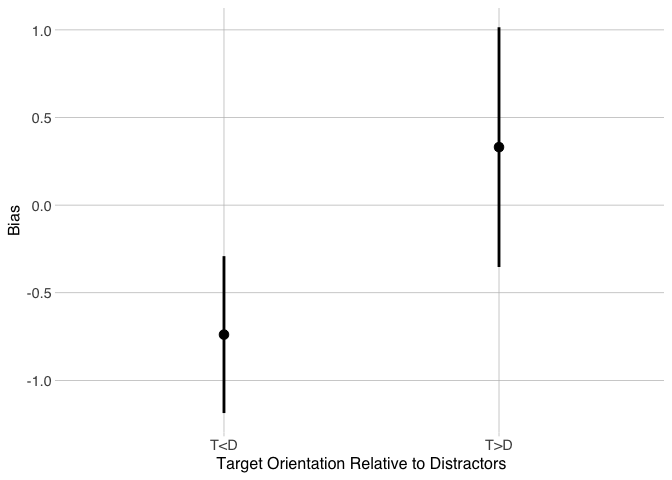

```r
plot_raifei <- plot.pointrange(data_raifei, aes(x = target_distr_rel, y = be_c), wid = 'participant', do_aggregate = T)+labs(y = 'Bias', x = 'Target Orientation Relative to Distractors')

plot_raifei
```

```r
# for tests, you can use ANOVA
ezANOVA(data = data_raifei, dv = be_c, wid = participant, within = target_distr_rel )
```

```
## $ANOVA
##             Effect DFn DFd       F         p p<.05       ges
## 2 target_distr_rel   1  19 6.72895 0.0178109     * 0.1648493
```

```r
# or just a t-test
t.test(be_c~target_distr_rel, data_raifei[,.(be_c = mymean(be_c)), by = .(participant, target_distr_rel)])
```

```
##
##  Welch Two Sample t-test
##
## data:  be_c by target_distr_rel
## t = -2.7388, df = 32.754, p-value = 0.009896
## alternative hypothesis: true difference in means is not equal to 0
## 95 percent confidence interval:
##  -1.8646446 -0.2748452
## sample estimates:
## mean in group T<D mean in group T>D
##        -0.7388362         0.3309087
```

```r
# write the function to simulate the data by condition
simulate_mix_raifei <- function (n_subjects, n_trials, mean_est, cov_mat, avg_sd){
  # generate means by subject
  sim_data <- data.table(mvrnorm(n = n_subjects, mean_est, cov_mat))
  # create subject IDs
  sim_data[, participant := 1:.N]
  # for each condition, generate trials
  sim_data[,rbind(
    data.frame(target_distr_rel = 'T<D', be_c = rnorm(n_trials, `T<D`, avg_sd)),
    data.frame(target_distr_rel = 'T>D', be_c = rnorm(n_trials, `T>D`, avg_sd))), by = .(participant)]
}

# get the distribution of means and sds
mean_sd_by_subj <- data_raifei[,data.frame(t(smean.sd(be_c))), keyby = .(participant, target_distr_rel)]

# reshaping to get mean for each subject in rows
mean_sd_by_subj_re <- dcast(mean_sd_by_subj, participant ~ target_distr_rel, value.var = 'Mean')

# get means by conditon
mean_est <- mean_sd_by_subj[, mean(Mean), by = .(target_distr_rel)]$V1

# get covariance matrix
cov_mat <- var(mean_sd_by_subj_re[,.(`T<D`, `T>D`)])

# get average SD
avg_sd <- mean_sd_by_subj[,mymean(SD)]

n_trials <- data_raifei[,.N, keyby = .(participant, target_distr_rel)][,mean(N)]

# example: simulate data with the original number of trials and subjects
ex_sim <- simulate_mix_raifei(n_subjects = 20, n_trials = round(n_trials), mean_est = mean_est, cov_mat = cov_mat, avg_sd = avg_sd)

ex_sim[,.N, by = .(participant, target_distr_rel)]
```

| participant | target_distr_rel | N |
| --- | --- | --- |
| 1 | T<D | 104 |
| 1 | T>D | 104 |
| 2 | T<D | 104 |
| 2 | T>D | 104 |
| 3 | T<D | 104 |
| 3 | T>D | 104 |
| 4 | T<D | 104 |
| 4 | T>D | 104 |
| 5 | T<D | 104 |
| 5 | T>D | 104 |

[output cut: 30 more lines]

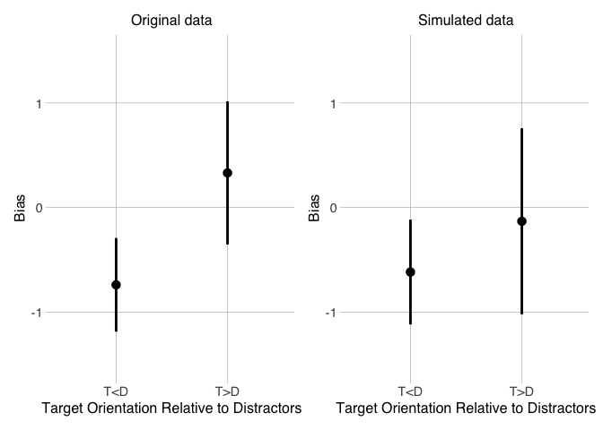

```r
# compare original and simulated data
p_sim <- plot.pointrange(ex_sim, aes(x = target_distr_rel, y = be_c), wid = 'participant', do_aggregate = T) +labs(y = 'Bias', x = 'Target Orientation Relative to Distractors', title = 'Simulated data')

(plot_raifei+ggtitle('Original data')+p_sim)*coord_cartesian(ylim = c(-1.5, 1.5))
```

```r
# create the second function to compute the power
simulate_mix_raifei_aggr <- function (n_subjects, n_trials, mean_est, cov_mat, avg_sd){
  sim_data <- simulate_mix_raifei(n_subjects, n_trials, mean_est, cov_mat, avg_sd)

  # average by condition x subject, compute p value
  sim_data[,.(be_c = mean(be_c)), by = .(participant, target_distr_rel)][,t.test(be_c~target_distr_rel, paired = T)$p.value]
}

sim_dt_by_trial_raifei <- data.table(expand.grid(n_subjects = c(10,20,40,100), n_reps = 1:max_n_reps, n_trials = seq(100, 500, 100)))
sim_dt_by_trial_raifei
```

| n_subjects | n_reps | n_trials |
| --- | --- | --- |
| 10 | 1 | 100 |
| 20 | 1 | 100 |
| 40 | 1 | 100 |
| 100 | 1 | 100 |
| 10 | 2 | 100 |
| 20 | 2 | 100 |
| 40 | 2 | 100 |
| 100 | 2 | 100 |
| 10 | 3 | 100 |
| 20 | 3 | 100 |

[output cut: 9990 more lines]

```r
# compute p-value for each replication and each sample size and trial number
sim_dt_by_trial_raifei[, p_val:= simulate_mix_raifei_aggr(n_subjects, n_trials = n_trials, mean_est, cov_mat, avg_sd), by = .(n_subjects, n_reps, n_trials)]
```

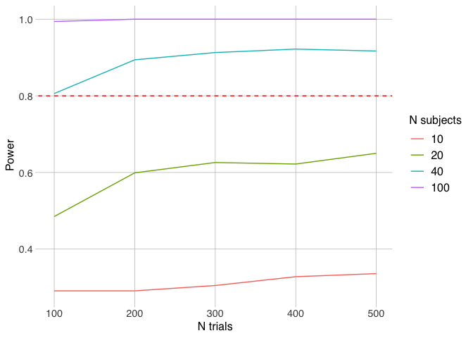

```r
sim_dt_by_trial_raifei_avg<-sim_dt_by_trial_raifei[,.(power = mean(as.numeric(p_val<0.05))), by = .(n_subjects,n_trials) ]

ggplot(sim_dt_by_trial_raifei_avg, aes(x = n_trials, color = factor(n_subjects), y = power))+
  geom_line(stat='summary', fun.y = mean)+
  labs(y = 'Power', x = 'N trials', color = 'N subjects')+
   geom_hline(yintercept = 0.8, linetype = 2, color = 'red')
```